# Modelos de población matriciales

José Jiménez

10/3/2023

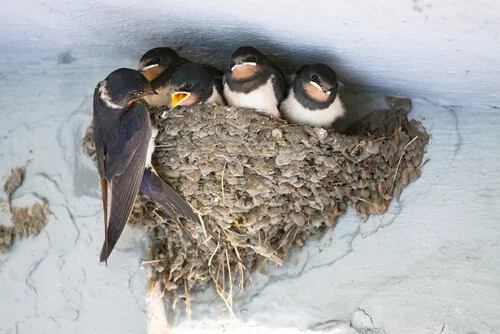

### Caso de estudio: Golondrina común *Hirundo rustica*

Vamos a considerar el caso más simple de una matriz de proyección o transición.

Definimos los parametros vitales que utilizaremos -combinados- para crear la matriz de población:

$$\begin{align*}
&f_{1}= 1.50 && \text{ # Fecundidad de las hembras juveniles
(de primer año)}\\
&f_{2}= 3.00 && \text{ # Fecundidad de las hembras adultas
(de más de un año)}\\
&s_{0}= 0.20 && \text{ # Supervivencia de los pollos (edad:
< 1)}\\
&s_{1}= 0.50 && \text{ # Supervivencia juvenil (edad: 1)}\\
&s_{2}= 0.65 && \text{ # Supervivencia adulta (edad: >
1)}\\
\end{align*}$$
Inmediatamente antes de la reproducción, la productividad y la supervivencia se pueden expresar en función de estos parámetros, y así, los pollos en un año *t+1* va a depender de la supervivencia y la productividad de las hembras de primer año y adultas en el año *t*, y la población reproductora en ese año *t+1* va a depender de la supervivencia de las hembras de primer año y adultas en el año *t*:

$$\begin{aligned}
N_{1,t+1}=& s_{0}*f_{1}*N_{1,t}+s_{0}*f_{2}*N_{2,t} &&
\text{ # Número de pollos producidos}\\
N_{2,t+1}=& s_{1}*N_{1,t}+s_{2}*N_{2,t} && \text{ # Número
de juveniles y adultos en la población}\\
\end{aligned}$$

Eso, en forma matricial, es:

$$\begin{bmatrix}
N_{1}\\N_{2}\\
\end{bmatrix} = \begin{bmatrix}s_{0}*f_{1} & s_{0}*f_{2}\\
s_{1} & s_{2}
\end{bmatrix}*\begin{bmatrix}N_{1}\\N_{2}\end{bmatrix}\\$$

Podemos sustituir por los valores:

$$\begin{bmatrix}
N_{1}\\N_{2}\\
\end{bmatrix} = \begin{bmatrix}0.30 & 0.60\\
0.50 & 0.65
\end{bmatrix}*\begin{bmatrix}N_{1}\\N_{2}\end{bmatrix}\\$$
Vamos a hacer una proyección en R usando esa matriz *A*:

```r
f1 <- 1.5   # Fecundidad de edad clase 1 (hembras de primer año)
f2 <- 3     # Fecundidad de edad clase 2 (hembras de 2 años o mas)
s0 <- 0.2   # Supervivencia de los pollos
s1 <- 0.5   # Supervivencia juvenil
s2 <- 0.65  # Supervivencia adulta

A <- matrix(c(
  s0*f1, s0*f2,
  s1,    s2), nrow = 2, byrow = TRUE)
A
```

```
##      [,1] [,2]
## [1,]  0.3 0.60
## [2,]  0.5 0.65
```

Y el periodo de tiempo en el que vamos a hacer la proyección:

```r
tspan <- 20            # período de tiempo
rows <- dim(A)[1]
```

Creamos unas matrices para contener los resultados

```r
n <- matrix(0,rows,tspan)     # abundancia, por clases de edad
N <- matrix(0,tspan,1)        # abundancia total
gr <- matrix(0,tspan-1,1)     # tasa de crecimiento, por años
```

Población inicial por clases de edad:

```r
n[,1] <- c(10,0)
```

### Resultados

```r
for (t in 1:(tspan-1)) {
  n[,t+1] <- A%*%n[,t]              # %*% = multiplicación del matrices en R
  N[t+1] <- sum(n[,t+1])
  gr[t] <- sum(n[,t+1])/sum(n[,t])  # tasa de crecimiento
}
```

Abundancia por edades

```r
round(n,1)
```

```
##      [,1] [,2] [,3] [,4] [,5] [,6] [,7] [,8] [,9] [,10] [,11] [,12] [,13] [,14]
## [1,]   10    3  3.9    4  4.2  4.4  4.7  4.9  5.1   5.4   5.7   5.9   6.2   6.6
## [2,]    0    5  4.8    5  5.3  5.5  5.8  6.1  6.4   6.7   7.1   7.4   7.8   8.2
##      [,15] [,16] [,17] [,18] [,19] [,20]
## [1,]   6.9   7.2   7.6     8   8.4   8.8
## [2,]   8.6   9.0   9.5    10  10.5  11.0
```

Abundancia total

```r
round(N,1)
```

```
##       [,1]
##  [1,]  0.0
##  [2,]  8.0
##  [3,]  8.7
##  [4,]  9.1
##  [5,]  9.5
##  [6,] 10.0
##  [7,] 10.5
##  [8,] 11.0
##  [9,] 11.6
## [10,] 12.1
## [11,] 12.7
## [12,] 13.4
## [13,] 14.1
## [14,] 14.8
## [15,] 15.5
## [16,] 16.3
## [17,] 17.1
## [18,] 17.9
## [19,] 18.8
## [20,] 19.8
```

Tasa de crecimiento ($\lambda$)

```r
round(gr,3)
```

```
##        [,1]
##  [1,] 0.800
##  [2,] 1.081
##  [3,] 1.047
##  [4,] 1.050
##  [5,] 1.050
##  [6,] 1.050
##  [7,] 1.050
##  [8,] 1.050
##  [9,] 1.050
## [10,] 1.050
## [11,] 1.050
## [12,] 1.050
## [13,] 1.050
## [14,] 1.050
## [15,] 1.050
## [16,] 1.050
## [17,] 1.050
## [18,] 1.050
## [19,] 1.050
```

Ploteamos la evolución temporal de la población total

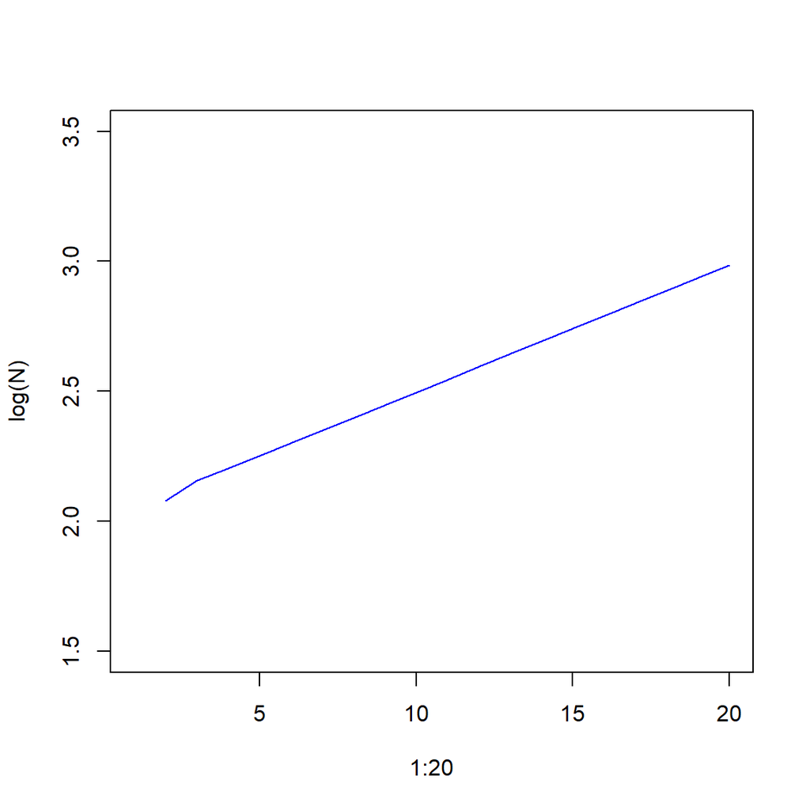

```r
plot(1:20,log(N), type="l", col="blue", ylim=c(1.5,3.5))
```

Vamos a calcular sensibilidad y elasticidad

```r
library(popbio)
gol.vr <- list(s0=0.2, s1=0.5, s2=0.65,f1=1.5, f2=3)
el <- expression(s0*f1, s0*f2,
                 s1,    s2)

vitalsens(el, gol.vr)
```

```
##    estimate sensitivity elasticity
## s0     0.20  1.82608696 0.34782609
## s1     0.50  0.52173913 0.24844720
## s2     0.65  0.65217391 0.40372671
## f1     1.50  0.06956522 0.09937888
## f2     3.00  0.08695652 0.24844720
```

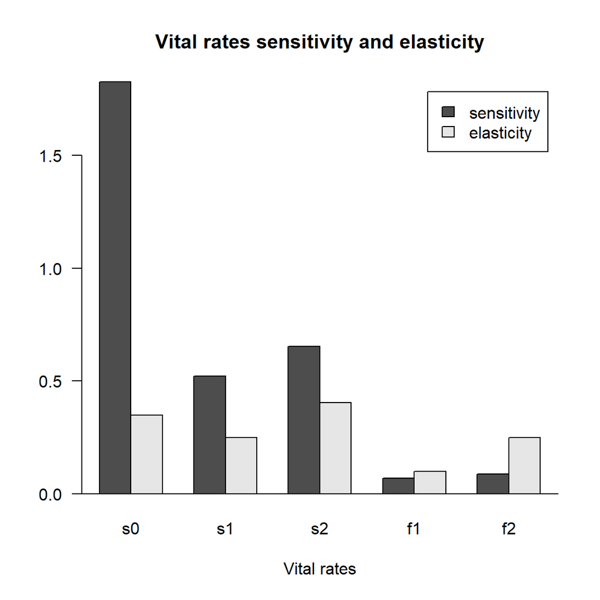

```r
barplot(t(vitalsens(el, gol.vr)[,2:3]), beside=TRUE, legend=TRUE, las=1, xlab="Vital rates",
main="Vital rates sensitivity and elasticity")
abline(h=0)
```

Veamos como el efecto en los cambios en los ratios vitales afecta a la tasa de crecimiento. Con el análisis de sensibilidad se evaluan los cambios absolutos en la tasa de crecimiento poblacional ($\lambda$), y con el análisis de elasticidad la contribución porcentual de cada ratio vital.

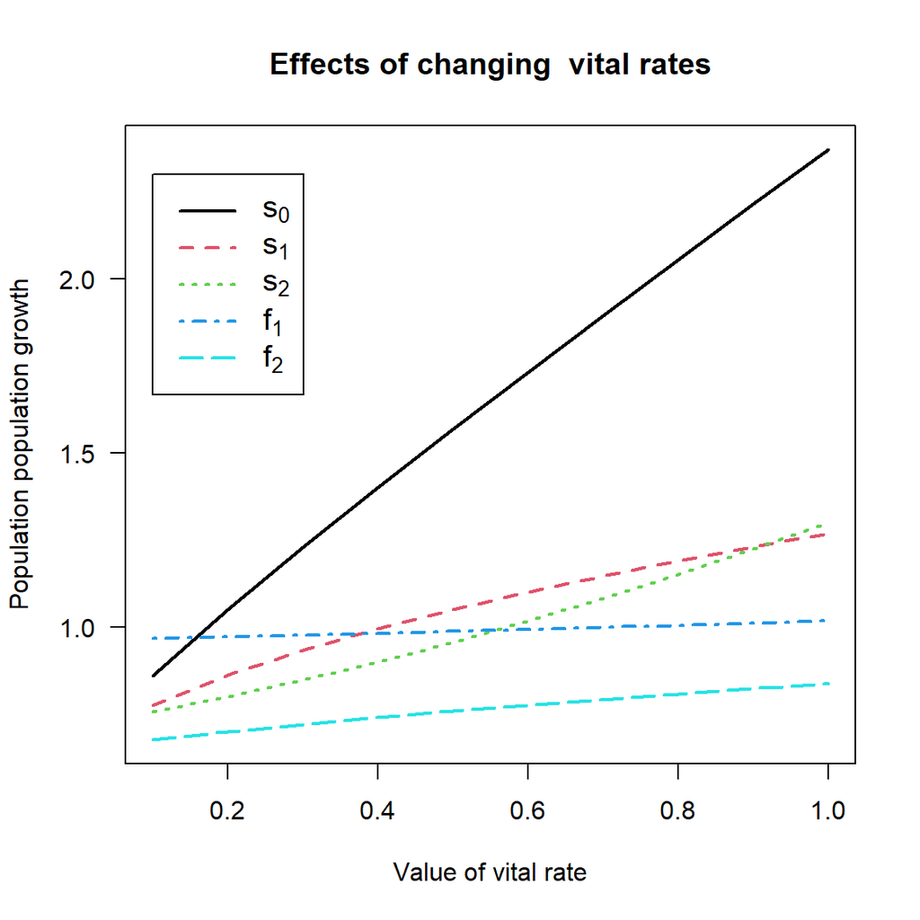

```r
n <- length(gol.vr)
vr <- seq(0.1,1,.1)

vrsen <- matrix(numeric(n*length(vr)), ncol=n, dimnames=list(vr, names(gol.vr)))
for (h in 1:n) {
   gol.vr2 <- list(s0=0.2, s1=0.5, s2=0.65,f1=1.5, f2=3)
   for (i in 1:length(vr)){
      gol.vr2[[h]] <- vr[i]
      A <- matrix(sapply(el, eval,gol.vr2 , NULL), nrow=sqrt(length(el)), byrow=TRUE)
      vrsen[i,h] <- max(Re(eigen(A)$values))
   }
}
matplot(rownames(vrsen), vrsen, type='l', lwd=2, las=1,
ylab="Population population growth", xlab="Value of vital rate",
main="Effects of changing  vital rates")
vrn <- expression(s[0], s[1], s[2], f[1], f[2])
legend(.1, 2.3, vrn, lty=1:5, lwd=2, col=1:5, cex=1.2)
```

En la golondrina la supervivencia de los pollos es muy importante para la tasa de crecimiento.